# CAPSTONE ML - SMS Spam Classification

Bayu Alansyah

7 Juli 2021

# 1 Introduction

Sebagai langkah terakhir dalam kursus Machine Learning Specialization, setiap siswa harus menyelesaikan 1 kasus sebagai machine learning capstone project ini. Dalam artikel ini, saya akan menjelaskan satu kasus machine learning capstone project mengenai : **“Spam SMS Classification”**.

Layanan Pesan Singkat (SMS) digunakan untuk mengirim pesan teks singkat dari satu perangkat seluler ke perangkat seluler lainnya. Layanan ini adalah jenis komunikasi yang sangat populer di antara orang-orang. Namun, tidak semua pesan SMS yang diterima dan inginkan merupakan pesan yang benar, karena terkadang terdapat pesan yang tidak diinginkan yang disebut dengan istilah `spam`.

Dalam Rpubs ini, kita akan melihat pengklasifikasian SMS menggunakan model machine learning Naive Bayes dan model Random Forest.

# 2 Load Library

Import beberapa library yang dibutuhkan. Adapun beberapa library yang akan digunakan untuk text mining adalah `dplyr`,`lubridate`,`tm`,`stopwords`,`tidyr`.

```r
library(dplyr)
library(lubridate)
library(tm)
library(stopwords)
library(e1071)
library(caret)
library(lime)
library(ggplot2)
library(tidyr)
library(tibble)
```

# 3 Import Data

Baca dan lihat data yang kita punya untuk dapat diolah :

```r
sms <- read.csv("data-input/data-train.csv", stringsAsFactors = F)
glimpse(sms)
```

```
## Rows: 2,004
## Columns: 3
## $ datetime <chr> "2017-02-15T14:48:00Z", "2017-02-15T15:24:00Z", "2017-02-15T1~
## $ text     <chr> "Telegram code 53784", "Rezeki Nomplok Dompetku Pengiriman Ua~
## $ status   <chr> "ham", "spam", "ham", "ham", "ham", "ham", "ham", "spam", "sp~
```

Data terdiri dari 2004 baris (rows) dan jumlah columns sebanyak 3 columns :

- `datetime` : Menampilkan kapan SMS dikirim
- `text` : Isi dari SMS
- `status` : Apakah SMS **Spam** atau **Ham**

Beberapa langkah yang akan dilakukan dalam preprocessing data, diantaranya :

- Mengubah teks menjadi corpus
- Membersihkan teks dari tanda baca, spasi, stopword, number
- Convert to document-term matrix

Sebelum melompat lebih jauh, mari kita lakukan Data Wrangling dan EDA terlebih dahulu.

# 4 Data Wrangling

Dalam Data Wrangling akan mengubah tipe data `datetime` menjadi date, `status` menjadi `factor`. (untuk columns text tidak perlu dirubah karena sudah tepat bertipe data character).

```r
sms <- sms %>%
   mutate(
      status=as.factor(status),
      datetime=ymd_hms(datetime)
   )
```

# 5 Exploratory Data Analytics (EDA)

Untuk dapat melihat pada jam berapa `spam` dan `ham` SMS paling banyak dikirim dalam sehari. Kita dapat melihatnya dalam visualisasi, untuk visualisasinya kita dapat menggunakan plot Bar.

Sebelumnya lakukan terlebih dahulu preprocesess data untuk visualisasi dengan mengelompokkan data berdasarkan jam dan jumlah total `spam`, `ham`. Dan kemudian plot menggunakan **geom_bar** pada **ggplot*.

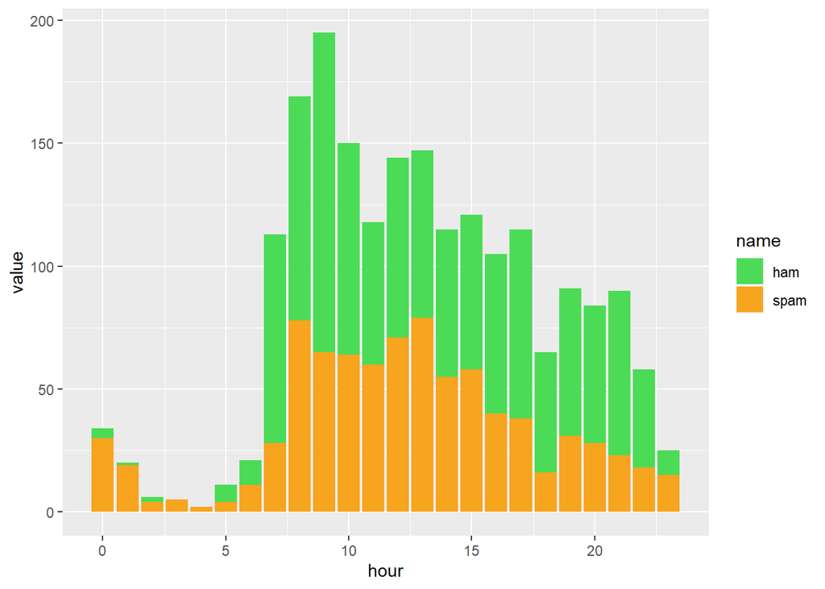

```r
sms %>%
   mutate(hour = hour(datetime)) %>%
   group_by(hour) %>%
   summarise(
      spam = sum(ifelse(status == "spam", 1, 0)),
      ham = sum(ifelse(status == "spam", 0, 1)),
   ) %>%
   ungroup() %>%
   pivot_longer(cols = c(ham, spam)
                ) %>%
  ggplot(
      aes(
         x=hour,
         y=value,
         fill=name
         )
      ) +
  geom_col(
    stat="identity"
    ) +
  scale_fill_manual(values=c("#4bdb57", "#f7a41e"))
```

Selain dapat melihat pada jam berapa `spam` dan `ham` SMS paling banyak dikirim dalam sehari. Kita pun dapat melihat pola text `spam` atau `ham` dengan menggunakan library **wordcloud**. Mari kita lihat pola teks `spam` pada data yang kita miliki

```r
library(wordcloud)
# your code here
sms %>%
  filter(status == "spam") %>%
  head(10) %>%
  pull(text)
```

```
##  [1] "Rezeki Nomplok Dompetku Pengiriman Uang! Kirim uang di Alfamart & dptkan hadiah jutaan rupiah setiap hari.Periode s.d. 28Feb17.Info: http://bit.ly/dmpurna MFI1"
##  [2] "YEAY! Free Ice Tea atau Cashback up to 30% dg transaksi  di AH Resto! Hanya untuk pengguna TCASH TAP. S&K Berlaku. Info tsel.me/tappromo"
##  [3] "Voting your Offer. Disc 40%, 1 crispy chicken+1 spicy chicken+ nasi+lotteria tea Rp.26rb. Tukar SMS ini di LOTTERIA terdekat. Berlaku hari ini. SKB. Promo *606#"
##  [4] "Ayo bergabung dgn Freedom Postpaid! Makin rame makin seru, ajak teman & keluarga diskonnya lebih besar. Daftar di http://im3.do/uxU PAI1"
##  [5] "Nikmati kemudahan mewujudkan impian kamu dan pasangan utk masa depan yg lebih cerah. Cek Dana Bantuan Sahabat di DOMPETKU! Info: http://bit.ly/dmpdbs MFI3"
##  [6] "Gratis 1 bulan Spotify Premium khusus FreedomCombo. Bisa bebas dengar musik,bikin playlist sepuasnya tanpa iklan dgn Spotify Premium. Aktifkan di *123*123# CVI1"
##  [7] "Masukan Username & Password ini di aplikasi Spotify. Username:085722688068 Password:1khF1SpC Mohon lgsg ganti alamat email & password di aplikasi Spotify."
##  [8] "TIPS HEMAT DATA: pakai resolusi 480p ketika menonton video online, temukan di setting layanan video yg kamu nikmati. Ini akan membuat pemakaian data lbh hemat"
##  [9] "Ayam (syp/paha bwh),Nasi,Ades Rp.18.181. Add on CD Bebi Glenn Rp.22.727. Tkr SMS hari ini di CFC CIBUBUR JUNC. Selama persediaan msh ada. Promo*606#"
## [10] "YEAY! Kejutan cashback & freebies dg TCASH TAP! Terus #pakeTCASH, cek HP kamu & dapatkan kejutannya. S&K berlaku. Info cek tsel.me/yeay"
```

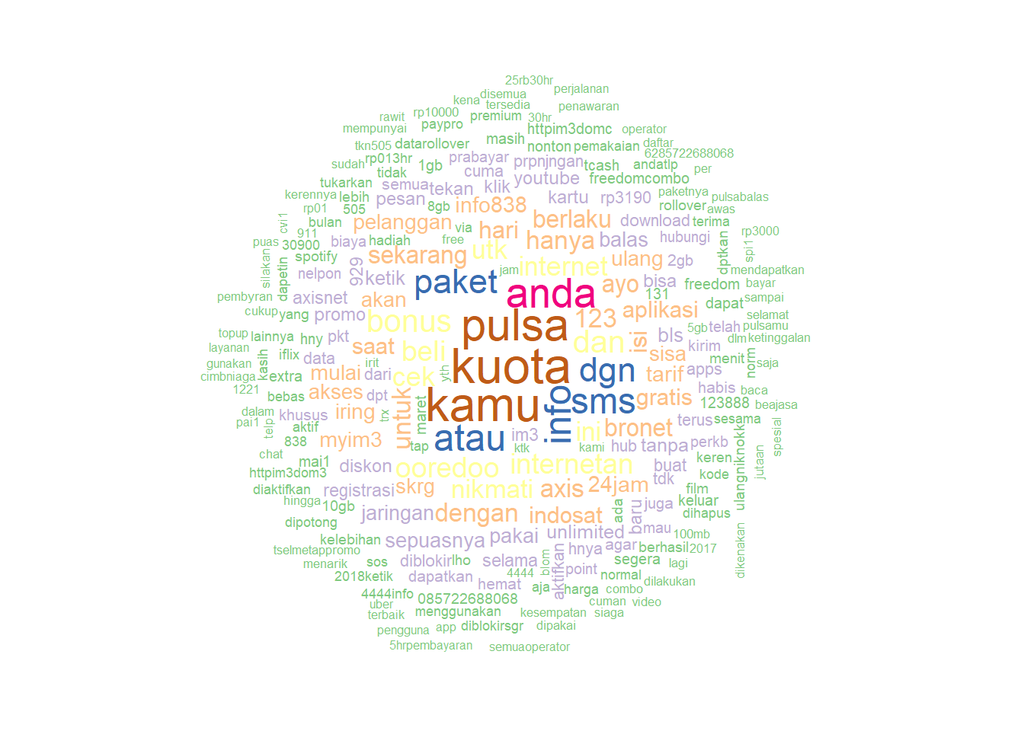

```r
sms %>%
  filter(status == "spam") %>%
  pull(text) %>%
  wordcloud(max.words = 250,
            scale = c(2, 0.4),
            random.order = FALSE,
            colors = brewer.pal(7, "Accent"))
```

Dari pola teks yang terbentuk diatas Kata yang berpotensial mengindikasi bahwa suatu text adalah spam yaitu: kuota, pulsa, paket, sms, internetan, info, atau, data, promo, diskon, gratis, bonus..

## 5.1 Data Characteristic

Filter data Untuk melihat characteristic dari kedua kategori, yaitu spam dan ham.

### 5.1.1 Spam

```r
sms %>%
   filter(status == "spam") %>%
   tail()
```

```
##                datetime
## 837 2018-03-30 20:26:00
## 838 2018-03-31 03:07:00
## 839 2018-03-31 05:40:00
## 840 2018-03-31 05:40:00
## 841 2018-03-31 13:02:00
## 842 2018-03-31 13:07:00
##                                                                                                                                                                     text
## 837             Terima kasih kesetiaanmu pada AXIS! BONUS NONTON film SEPUASNYA di Iflix & KZLGAMES tgl 31Mar-1Apr. Hubungi *969# utk aktifkan BONUSnya. Info 838 AFO01A
## 838                                    (AXIS) Kuota utama paket internet kamu telah digunakan seluruhnya. Penggunaan selanjutnya akan dikenakan tarif normal ya. Info838
## 839                 PAKET BRONET 24JAM 100MB 1hr Rp3500 kamu sudah tidak aktif. Gunakan terus AXISmu dan temukan promo menarik AXIS lainnya di aplikasi AXISnet. Info838
## 840              PAKET BRONET 4G OWSEM 4GB 30hr Rp38900 kamu sudah tidak aktif. Gunakan terus AXISmu dan temukan promo menarik AXIS lainnya di aplikasi AXISnet. Info838
## 841              AGAR TDK DIBLOKIR,sgr registrasi ulang kartu prabayar Anda.Tlp dan SMS keluar diblokir mulai 1-31 Maret 2018.Ketik ULANG#NIK#No.KK SMS ke 4444.Info 838
## 842 Asik nih!Balas YA, Km bisa menangin:\n- Rp 500 Juta\n- 500gr EMAS\n- Rp 75 JutaGRATIS\nIkutan kuisnya TANPA BIAYA dr AXIS!Balas YA\nInfo: axisnet.id/fantaxis PFF11B
##     status
## 837   spam
## 838   spam
## 839   spam
## 840   spam
## 841   spam
## 842   spam
```

> Dari apa yang terlihat di atas, teks yang berhubungan dengan spam biasanya bersifat promosi. Dan beberapa kata/token seperti “gratis”, “bonus”.

### 5.1.2 Ham

```r
sms %>%
   filter(status == "ham") %>%
   tail()
```

```
##                 datetime
## 1157 2018-03-28 13:20:00
## 1158 2018-03-28 13:21:00
## 1159 2018-03-28 14:37:00
## 1160 2018-03-28 15:53:00
## 1161 2018-03-31 13:04:00
## 1162 2018-03-31 21:17:00
##                                                                                                                                                                  text
## 1157                                                                                                                                              Telegram code 89789
## 1158                                                                                                                                              Telegram code 89789
## 1159  Only for Staff! Register w/CIMBNiaga email at shop.samsung .com/id_epp/cimbniaga. Disc upto 30%+Add Disc selected items +0% upto 24mos till 31Mar18. Info 14041
## 1160 Cashback IDR500,000 limited for first 100 cardholders + 0% upto 24 mos with Credit Card at Tory Burch boutiques Jakarta&Surabaya, till 31Mar'18. T&C. Info 14041
## 1161           PERHATIAN!\nKartu AXIS-mu sdh dlm masa peringatan!Registrasikan skrg jg agar tdk terblokir,ke *123*4444# atau telp 838.BONUS kuota 1GB slm 7hr. AAG23C
## 1162                                                                                                                                                      Dimana de ?
##      status
## 1157    ham
## 1158    ham
## 1159    ham
## 1160    ham
## 1161    ham
## 1162    ham
```

> Teks yang ham biasanya terkait dengan nomor verifikasi atau informasi provider atau percakapan biasa. Beberapa kata yang digunakan adalah “kode”, “dimana”.

# 6 Data Preparation

Karena teks dalam data adalah teks SMS yang bersifat mentah atau murni. kita harus membersihkannya terlebih dahulu sehingga model yang kita buat nantinya dapat menggunakan teks tersebut untuk proses training.

Ada beberapa tahapan yang harus kita lalui.

## 6.1 Convert to Corpus

Langkah pertama adalah mengubah teks menjadi corpus. > Corpus adalah kumpulan dokumen

```r
sms.corpus <- sms %>%
   # Convert to corpus
   VectorSource() %>%
   VCorpus()
```

## 6.2 Text Cleaning

Setelah itu, sekarang kita dapat membersihkan teks tersebut. Beberapa hal yang perlu kita lakukan adalah sebagai berikut :

- Mengubah teks menjadi huruf kecil
- Menghapus nomor (remove numbers)
- Hapus kata-kata stopwords (Karena dalam dataset menggunakan bahasa indonesia. Kita perlu menghapus stopwords khusus untuk bahasa Indonesia).
- Hapus tanda baca (remove punctuation)
- Stem Document (Mengubah kata menjadi kata basic)
- Strip whitespace menghapus extra white space

```r
sms.corpus <- sms.corpus %>%
   tm_map(content_transformer(tolower)) %>%
   tm_map(removeNumbers) %>%
   tm_map(removeWords, stopwords("id", source="stopwords-iso")) %>%
   tm_map(removePunctuation) %>%
   tm_map(function(x) { stemDocument(x, language="indonesian") }) %>%
   tm_map(stripWhitespace)
```

## 6.3 Convert to Document Term Matrix

Setelah teks bersih. Pertanyaan selanjutnya adalah bagaimana kita bisa membuat model jika prediktornya masih berupa teks.

Dalam text mining, teks biasanya berubah menjadi Document-Term Matrix (DTM) dengan proses tokenization. Tokenisasi dapat membagi satu kalimat menjadi beberapa istilah. Term dapat berupa satu kata, dua kata atau lebih. Dalam DTM, satu kata sama dengan 1 prediktor, dengan nilai seberapa sering kata tersebut muncul dalam satu dokumen atau sms.

```r
sms.dtm <- sms.corpus %>%
   DocumentTermMatrix()

sms.dtm
```

```
## <<DocumentTermMatrix (documents: 3, terms: 2827)>>
## Non-/sparse entries: 2828/5653
## Sparsity           : 67%
## Maximal term length: 79
## Weighting          : term frequency (tf)
```

**Dapatkan hanya istilah yang paling sering ?**

Dari hanya mendapatkan term paling sering dengan minimal muncul dalam 20 sms, kita bisa mendapatkan kandidat prediktor paling berpengaruh.

```r
sms.freq <- findFreqTerms(sms.dtm, lowfreq = 20)

sms.dtm <- sms.dtm[,sms.freq]
```

Dengan memfilter prediktor yang paling berpengaruh, kita dapat mengurangi waktu untuk melatih model.

## 6.4 Convert to Bernoulli

Dalam referensi istilah dokumen, nilai matriks adalah rentang frekuensi dari 0 hingga Tak Terbatas. Untuk menghitung probabilitas, frekuensi perlu disederhanakan menjadi 0 dan 1 atau tidak muncul dan muncul.

Untuk melakukan itu kita perlu membangun custom function bernama Bernoulli Converter.

Logika di baliknya sangat sederhana

```r
bernoulli_conv <- function(x) {
  x <- as.factor(ifelse(x > 0, 1, 0))
  return(x)
}

bernoulli_conv(c(0,1,3))
```

```
## [1] 0 1 1
## Levels: 0 1
```

Seperti yang kita lihat, custom function berfungsi, sekarang mari kita terapkan ke dataset yang kita miliki.

```r
sms.dtm <- sms.dtm %>%
   apply(MARGIN = 2, FUN = bernoulli_conv)

sms.dtm[1:3, 1:20]
```

```
##     Terms
## Docs aja aks aktif aktifkan aplikasi app aspen axi axisnet ayo bala bank beba
##    1 "0" "0" "0"   "0"      "0"      "0" "0"   "0" "0"     "0" "0"  "0"  "0"
##    2 "1" "1" "1"   "1"      "1"      "1" "1"   "1" "1"     "1" "1"  "1"  "1"
##    3 "0" "0" "0"   "0"      "0"      "0" "0"   "0" "0"     "0" "0"  "0"  "0"
##     Terms
## Docs beli berhasil berita berlaku bersifat biaya blm
##    1 "0"  "0"      "0"    "0"     "0"      "0"   "0"
##    2 "1"  "1"      "1"    "1"     "1"      "1"   "1"
##    3 "0"  "0"      "0"    "0"     "0"      "0"   "0"
```

## 6.5 Create a Function

Untuk persiapan data yang baru saja dilakukan, kita dapat merangkum semua itu ke dalam sebuah fungsi.

```r
tokenize_text <- function(x, is_bernoulli = TRUE) {
   data_dtm <- x %>%
      # Convert to corpus
      VectorSource() %>%
      VCorpus() %>%

      # text cleaning
      tm_map(content_transformer(tolower)) %>%
      tm_map(removeNumbers) %>%
      tm_map(removeWords, stopwords("id", source="stopwords-iso")) %>%
      tm_map(removePunctuation) %>%
      tm_map(stemDocument) %>%
      tm_map(stripWhitespace) %>%

      # Convert DTM
      DocumentTermMatrix()

   data_freq <- findFreqTerms(data_dtm, lowfreq = 20)

   if (is_bernoulli) {
      data_dtm[,data_freq] %>%
         apply(MARGIN = 2, FUN = bernoulli_conv) %>%
         return()
   } else {
      data_dtm[,data_freq] %>%
         return()
   }
}
```

# 7 Cross Validation

Setelah membersihkan data, sekarang mari kita pisahkan data untuk dilatih dan diuji. Untuk kasus ini kita akan membagi menjadi 75% data train dan 25% data test.

```r
RNGkind(sample.kind = "Rounding")
```

```r
set.seed(100)

index <- sample(nrow(sms), nrow(sms)*0.75)

sms_clean <- tokenize_text(sms$text)

data_train_clean <- sms_clean[index,]
data_test_clean <- sms_clean[-index,]

label_train <- sms[index, "status"]
label_test <- sms[-index, "status"]
```

```r
data_train <- sms[index,]
data_test <- sms[-index,]
```

# 8 Model

Untuk model, kita akan membuat dua model yang berbeda sebagai perbandingan. Naive Bayes dan Random Forest.

## 8.1 Naive Bayes

Membuat model naive bayes.

```r
model_nb <- naiveBayes(
   x = data_train_clean,
   y = label_train,
   laplace = 1
)
```

## 8.2 Random Forest

Sebagai perbandingan, kita membuat model random forest.

> **Peringatan!** Dalam membuat model random forest dapat memakan waktu yang cukup lama, beberapa menit atau bahkan berjam-jam. Jadi sangat membantu apabila menyimpan model setelah model dibuat.

```r
# set.seed(417)
#
# ctrl <- trainControl(method="repeatedcv", number = 5, repeats = 3)
#
# model_forest <- train(
#    x = data_train_clean,
#    y = label_train,
#    method = "rf",
#    trControl = ctrl
# )
#
# saveRDS(model_forest, "spam_Rforest.RDS") # save model
```

Memuat model random forest

```r
model_forest <- readRDS("spam_Rforest.RDS")
```

# 9 Evaluate Model

Setelah membuat model, mari lakukan evaluasi pada model yang telah dibuat

## 9.1 Prediction

Tetapi, kita perlu membuat prediksi agar dapat dievaluasi dengan data test

### 9.1.1 Naive Bayes

```r
sms_pred_naive <- predict(model_nb, newdata = data_test_clean, type="class")
head(sms_pred_naive)
```

```
## [1] ham  spam spam ham  ham  ham
## Levels: ham spam
```

### 9.1.2 Random Forest

```r
sms_pred_rf <- predict(model_forest, newdata = data_test_clean, type="raw")
head(sms_pred_rf)
```

```
## [1] ham  spam spam ham  spam spam
## Levels: ham spam
```

## 9.2 Confusion Matrix

Untuk mengevaluasi model mari kita membuat Confusion Matrix.

Untuk kasus klasifikasi SMS ini. Akan digunakan Accuracy untuk mengukur kinerja model karena menentukan nilai positif atau Spam sama pentingnya dengan menentukan nilai negatif atau Ham, karena kebanyakan orang tidak ingin melewatkan SMS penting, tetapi juga ingin menyingkirkan SMS spam.

### 9.2.1 Naive Bayes

```r
confusionMatrix(data = sms_pred_naive, reference = label_test, positive = "spam")
```

```
## Confusion Matrix and Statistics
##
##           Reference
## Prediction ham spam
##       ham  257   17
##       spam  27  200
##
##                Accuracy : 0.9122
##                  95% CI : (0.8839, 0.9355)
##     No Information Rate : 0.5669
##     P-Value [Acc > NIR] : <2e-16
##
##                   Kappa : 0.8221
##
##  Mcnemar's Test P-Value : 0.1748
##
##             Sensitivity : 0.9217
##             Specificity : 0.9049
##          Pos Pred Value : 0.8811
##          Neg Pred Value : 0.9380
##              Prevalence : 0.4331
##          Detection Rate : 0.3992
##    Detection Prevalence : 0.4531
##       Balanced Accuracy : 0.9133
##
##        'Positive' Class : spam
##
```

Dari Confusion Matrix untuk prediksi naive bayes. Didapatkan 91% Accuracy. Hal ini menunjukkan bahwa model naive bayes cukup akurat.

### 9.2.2 Random Forest

```r
confusionMatrix(data = sms_pred_rf, reference = label_test, positive = "spam")
```

```
## Confusion Matrix and Statistics
##
##           Reference
## Prediction ham spam
##       ham  270    6
##       spam  14  211
##
##                Accuracy : 0.9601
##                  95% CI : (0.939, 0.9754)
##     No Information Rate : 0.5669
##     P-Value [Acc > NIR] : <2e-16
##
##                   Kappa : 0.9191
##
##  Mcnemar's Test P-Value : 0.1175
##
##             Sensitivity : 0.9724
##             Specificity : 0.9507
##          Pos Pred Value : 0.9378
##          Neg Pred Value : 0.9783
##              Prevalence : 0.4331
##          Detection Rate : 0.4212
##    Detection Prevalence : 0.4491
##       Balanced Accuracy : 0.9615
##
##        'Positive' Class : spam
##
```

Padahal model sebelumnya sudah cukup akurat dalam memprediksi data test. Model random forest ini lebih akurat daripada naive bayes dan mendapatkan 96% Accuracy untuk data test.

## 9.3 False Prediction

Mari kita lihat prediksi model mana yang salah. Untuk hasil prediksi random forest ini akan digunakan karena lebih robust dibandingkan naive bayes.

```r
pred.false <- data_test %>%
   mutate(
      pred.rf = sms_pred_rf,
   ) %>%
   filter(pred.rf != status)
pred.false %>% select(-datetime) %>% filter(pred.rf == "spam")
```

```
##                                                                                                                                                                text
## 1                  PT.Pertamina Bina Medika Menerima Karyawan Baru 2017 Dengan Berbagai Jurusan L/P, Info Lengkap Kunjungi : http://www.recruitment-pertamedika.com
## 2                                         LIMITED OFFER! 20% pembelian produk. Berlaku sampai 28 Februari 2017. S&K berlaku. Kunjungi ERHA terdekat. www.erha.co.id
## 3          Travelingnya happy, terbangnya aman, hotelnya nyaman karena dapat diskon AGODA 7% + Asuransi Gratis 25 Jt! Buruan ke sini http://bit.ly/AktifkanSekarang
## 4  Selamat Anda mendapatkan perlindungan dari PasarPolis.com. Segera daftar di http://bit.ly/2jY1FnY  Gratis tiket nonton utk 500 pendaftar pertama. Info S&K 14041
## 5     Langganan Spotify Premium kamu berakhir pd 2017-03-17. Pastikan pulsa kamu cukup utk trs menikmati jutaan musik tanpa iklan. Isi ulang di bit.ly/topupindosat
## 6  Freedom M Rp 55rb/30hr berhasil dprpanjang sd 17/09/2017 08:05. Nikmati BONUS KUOTA sd 10GB dismua jaringan,APPS TANPA KUOTA,DATA ROLLOVER. Cek http://im3.do/mc
## 7                    MAAF, Paket EXTRA yang Kamu pilih tidak tersedia. Silakan daftar Paket EXTRA atau Paket Lainnya di *123# atau http://mycare.indosatooredoo.com
## 8                      Uber: Anda mendapatkan potongan 50% hingga Rp 5000, untuk 10 perjalanan uberMOTOR Anda. Ayo pesan Uber-mu sekarang! http://t.uber.com/nguber
## 9                Pulsa tdk ckp utk prpanjang.Utk tetap menggunakan internet.silakan daftar Pkt Internet 50MB Rp5,000/hari dgn Ketik Ya jika setuju atau tarif perKB
## 10    Plgn 085722688068, +10 KOIN PULSA mu hari ini belum diambil? Hub *858*22# utk Ambil. Sayang lho ga diambil, bisa buat tuker pulsa. Hub *858*22# & Pilih 1 OK.
## 11                                                                             Registrasi Prabayar Sukses. Data pelanggan sesuai identitas  Anda telah didaftarkan.
## 12                    Nikmati akses ke FB, Path, Twitter,Whatsapp, BBM, Line,FB Msg, iFlix&Spotify gak habis habis kuotanya. Info *123# atau myIM3 http://im3.do/m3
## 13    Trm ksh Anda sdh akses Facebook dgn IndosatOoredoo. Brdasar pngalamn Anda, sberapa puas Anda thdp kualitas akses FB kami? Balas F1 sd F5 (F5= Sgt puas). FREE
## 14                    Waspada penipuan! Bank dan stafnya tidak pernah meminta data rahasia seperti PIN, password, passcode, user ID untuk alasan apapun. Info 14041
##    status pred.rf
## 1     ham    spam
## 2     ham    spam
## 3     ham    spam
## 4     ham    spam
## 5     ham    spam
## 6     ham    spam
## 7     ham    spam
## 8     ham    spam
## 9     ham    spam
## 10    ham    spam
## 11    ham    spam
## 12    ham    spam
## 13    ham    spam
## 14    ham    spam
```

Terlihat di atas banyak teks ham yang salah klasifikasi adalah sms dari provider internet yang menginformasikan penggunanya tentang sesuatu yang berguna seperti sisa data. Hal ini mungkin terjadi karena provider internet sering mengirimkan barang-barang promosi yang berisi kata-kata seperti “pulsa” atau “kuota” atau “paket” yang juga digunakan untuk menginformasikan kepada pengguna tentang sisa data atau sesuatu yang berguna bagi pengguna.

# 10 Interpreting Model

Ada dua metode yang akan digunakan untuk menginterpretasikan model ini. Variabel Pentingnya untuk random forest dan LIME untuk Naive Bayes.

## 10.1 Variable Importance

Variable Importance membantu kita mengetahui variabel mana yang berkontribusi lebih banyak dan variabel mana yang tidak berkontribusi apa pun.

Mari kita lihat kata mana yang paling penting, dengan menggunakan Variable Importance dari model `Random forest` yang dibuat.

```r
caret::varImp(model_forest, 20)$importance %>%
   as.data.frame() %>%
   rownames_to_column() %>%
   arrange(-Overall) %>%
   mutate(rowname = forcats::fct_inorder(rowname))
```

```
##            rowname      Overall
## 1             info 1.000000e+02
## 2            grati 4.192166e+01
## 3          ooredoo 3.955489e+01
## 4              ayo 3.488508e+01
## 5              ire 3.303942e+01
## 6        pelanggan 3.201549e+01
## 7            pulsa 2.567578e+01
## 8             beli 2.155334e+01
## 9              isi 2.140972e+01
## 10         berlaku 1.675947e+01
## 11           kuota 1.658621e+01
## 12      internetan 1.643414e+01
## 13             for 1.382660e+01
## 14          bronet 1.216712e+01
```

[output cut: 185 more lines]

Kontributor paling banyak dalam model adalah `info` dan kontributor paling sedikit adalah `memberitahukan`.

## 10.2 LIME

LIME atau kependekan dari Local Interpretable Model-agnostic Explanations adalah teknik penjelasan baru yang menjelaskan prediksi pengklasifikasi apa pun dengan cara yang dapat ditafsirkan dan dipercaya dengan mempelajari model yang dapat ditafsirkan secara lokal di sekitar prediksi.

LIME dapat memprediksi model apa saja dan memperlakukannya sebagai black box model. Sedangkan Decision Tree atau Variable Importance dalam Random Forest hanya berlaku pada model tersebut.

LIME akan digunakan untuk menginterpretasikan model naive bayes.

Karena lime tidak mendukung naiveBayes, kita perlu membuat custom function untuk naive bayes bernama `model_type.naiveBayes`.

```r
model_type.naiveBayes <- function(x){
  return("classification")
}
```

Selain itu dibutuhkan juga fungsi untuk menyimpan prediksi. Fungsinya adalah `predict_model.naiveBayes`.

```r
predict_model.naiveBayes <- function(x, newdata, type = "raw") {
    res <- predict(x, newdata, type = "raw") %>% as.data.frame()
    return(res)
}
```

Sekarang, kita perlu menyiapkan input untuk LIME. Dalam masalah klasifikasi umum, inputnya dapat berupa tabel yang berisi fitur-fitur. Namun, dalam klasifikasi teks, input harus berupa teks asli dan kita juga perlu memberikan langkah preprocessing untuk memproses teks dari pembersihan hingga tokenisasi. Pastikan input teks adalah karakter, bukan faktor.

```r
text_train <- data_train$text %>% as.character()
text_test <- data_test$text

explainer <- lime(
   text_train,
   model=model_nb,
   preprocess=tokenize_text
)
```

Akan menggunakan 5 features untuk ini

```r
set.seed(123)
explanation <- explain(
   text_test[1:5],
   explainer = explainer,
   n_labels = 1,
   n_features = 5,
   feature_select = "none",
   single_explanation = F
)
```

Visualisasi hasilnya

```r
plot_text_explanations(explanation)
```

[interactive chart not shown]

Teks berlabel biru berarti kata mendukung/meningkatkan kemungkinan menjadi **SPAM**, dengan pengaruh paling besar kata `promo` dan `belaku`.

Teks berlabel merah berarti bahwa kata tersebut bertentangan/mengurangi kemungkinan peninjauan menjadi **HAM**, seperti `Anda`, `hari` atau `nasi`.

> Perbedaan antara LIME dan menggunakan model machine learning yang dapat diinterpretasikan seperti Decision Tree adalah LIME dapat diterapkan dalam model apa pun tetapi menjelaskan peran fitur berdasarkan prediksi model dalam data sampel. Sedangkan model pembelajaran mesin interpretable hanya dapat diterapkan pada modelnya seperti Variable Importance in Random forest tetapi dapat menjelaskan apa kontribusi fitur dalam model itu sendiri.

# 11 Submission Data

Sekarang mari kita terapkan model kita ke Submission Data. Untuk ini kita akan menggunakan Random Forest karena lebih kuat dan akurat daripada Naive Bayes.

## 11.1 Import Data

Import Submission Data

```r
submission <- read.csv("data-input/data-test.csv")
```

## 11.2 Text Cleaning

Karena kita sudah membuat function tadi bernama `tokenize_text`.

```r
submission.clean <- tokenize_text(submission$text)
submission.clean[1:5,1:10]
```

```
##     Terms
## Docs aplikasi axi axisnet bala beli berlaku bonus bronet dgn diblokir
##    1 "0"      "0" "0"     "0"  "1"  "0"     "0"   "0"    "1" "0"
##    2 "0"      "0" "0"     "0"  "0"  "0"     "0"   "0"    "0" "0"
##    3 "0"      "0" "0"     "0"  "0"  "0"     "0"   "0"    "0" "0"
##    4 "0"      "0" "0"     "0"  "0"  "0"     "0"   "0"    "0" "0"
##    5 "0"      "0" "0"     "0"  "0"  "0"     "1"   "0"    "0" "0"
```

## 11.3 Optimize data

Karena Random Forest perlu memiliki prediktor yang sama. Kita perlu memangkas prediktor kita sehingga memiliki prediktor yang sama dengan data train. Mari kita buat function untuk itu dan beri nama `trimRfPredictor`.

```r
trimRfPredictor <- function(x, train_data) {
   x %>%
      as.data.frame() %>%
      fncols(colnames(train_data)) %>%
      select(colnames(train_data)) %>%
      mutate_all(as.factor) %>%
      as.matrix.data.frame() %>%
      return()
}
```

Selain itu, kita perlu membuat custom function untuk menambahkan kolom agar sesuai dengan prediktor data training. Kita bisa menamakannya `fncols`.

```r
fncols <- function(data, cname) {
  add <-cname[!cname%in%names(data)]

  if(length(add)!=0) data[add] <- as.factor("0")
  data
}
```

```r
submission.clean.df <- trimRfPredictor(submission.clean, data_train_clean)
submission.clean.df[1:5,1:20]
```

```
##   aja aks aktif aktifkan aplikasi app aspen axi axisnet ayo bala bank beba beli
## 1 "0" "0" "0"   "0"      "0"      "0" "0"   "0" "0"     "0" "0"  "0"  "0"  "1"
## 2 "0" "0" "0"   "0"      "0"      "0" "0"   "0" "0"     "0" "0"  "0"  "0"  "0"
## 3 "0" "0" "0"   "0"      "0"      "0" "0"   "0" "0"     "0" "0"  "0"  "0"  "0"
## 4 "0" "0" "0"   "0"      "0"      "0" "0"   "0" "0"     "0" "0"  "0"  "0"  "0"
## 5 "0" "0" "0"   "0"      "0"      "0" "0"   "0" "0"     "0" "0"  "0"  "0"  "0"
##   berhasil berita berlaku bersifat biaya blm
## 1 "0"      "0"    "0"     "0"      "0"   "0"
## 2 "0"      "0"    "0"     "0"      "0"   "0"
## 3 "0"      "0"    "0"     "0"      "0"   "0"
## 4 "0"      "0"    "0"     "0"      "0"   "0"
## 5 "0"      "0"    "0"     "0"      "0"   "0"
```

## 11.4 Predict Submission

Setelah membersihkan data. Mari kita memprediksi data dan menyimpannya.

### 11.4.1 Naive Bayes

```r
submission.nb <- submission %>%
   select(datetime)
submission.nb$status <- predict(model_nb, newdata = submission.clean.df, type="class")

head(submission.nb)
```

```
##               datetime status
## 1 2018-03-01T00:32:00Z    ham
## 2 2018-03-01T08:57:00Z    ham
## 3 2018-03-01T09:15:00Z   spam
## 4 2018-03-01T16:42:00Z    ham
## 5 2018-03-01T17:42:00Z    ham
## 6 2018-03-01T22:04:00Z    ham
```

```r
nrow(submission.nb)
```

```
## [1] 283
```

```r
write.csv(submission.nb, "data-input/submission_nb_bayu.csv")
```

### 11.4.2 Random Forest

```r
submission.rf <- submission %>%
   select(datetime)
submission.rf$status <- predict(model_forest, newdata = submission.clean.df, type="raw")

head(submission.rf)
```

```
##               datetime status
## 1 2018-03-01T00:32:00Z   spam
## 2 2018-03-01T08:57:00Z    ham
## 3 2018-03-01T09:15:00Z   spam
## 4 2018-03-01T16:42:00Z   spam
## 5 2018-03-01T17:42:00Z    ham
## 6 2018-03-01T22:04:00Z    ham
```

```r
nrow(submission.rf)
```

```
## [1] 283
```

```r
write.csv(submission.rf, "data-input/submission_rf_bayu.csv")
```

# 12 Conclusion

Untuk mengklasifikasikan apakah SMS adalah spam atau ham. Digunakan Naive Bayes dan Random Forest. Karena Random Forest lebih akurat daripada Naive Bayes. Jadi digunakanlah Random Forest untuk memprediksi test submission data dan mendapatkan Accuracy dan Sensitivity >80%, serta Spesificity dan Precision >90%. Ini membuktikan bahwa masalah tersebut dapat diselesaikan menggunakan Machine Learning.

# 13 Result

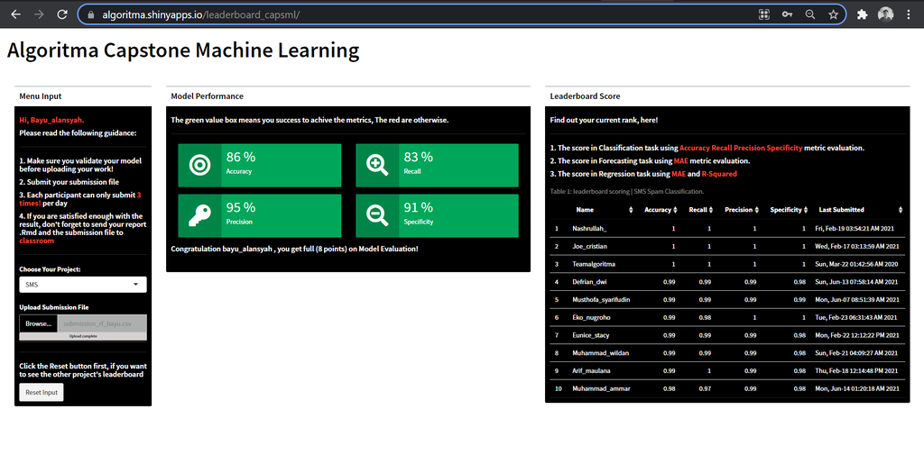